# November 5th Assignment

Author

Caleb Mukasa

## Problem 1

Hypotheses: H0: μ = 110 H1: μ ≠ 110

```r
library(ISLR2)
mean(Carseats$Price)
```

```
[1] 115.795
```

```r
sd(Carseats$Price)
```

```
[1] 23.67666
```

```r
n <- length(Carseats$Price)
t.test(Carseats$Price, mu=110) # Statistical Test
```

```
    One Sample t-test

data:  Carseats$Price
t = 4.8951, df = 399, p-value = 1.429e-06
alternative hypothesis: true mean is not equal to 110
95 percent confidence interval:
 113.4677 118.1223
sample estimates:
mean of x
  115.795
```

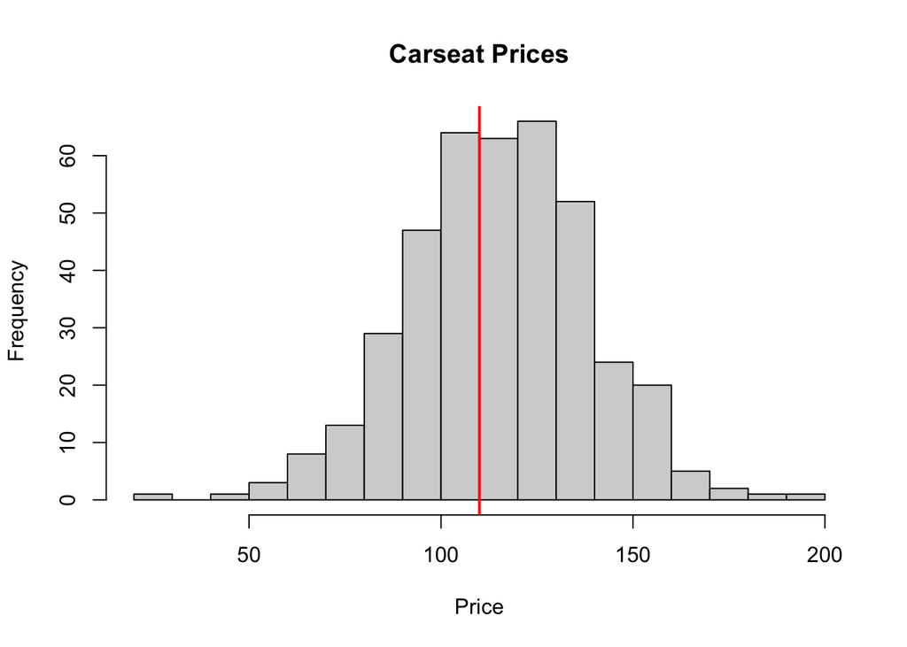

```r
plot.new() # Plotted a histogram to illustrate
hist(Carseats$Price,
     breaks = 20,
     main = "Carseat Prices",
     xlab = "Price")
abline(v = 110, col = "red", lwd = 2) # Having error plot.new has not been called yet for some reason however renders fine
```

The sample mean price is $115.80. If the true mean was 110, we would expect the sample mean to be somewhere near 110, maybe a bit above or below because of natural variation. But we would not expect it to land almost six dollars higher.

p-value is extremely small (≈ 1.4 × 10^-6). That means this difference is much too big to be explained by random chance if real average was actually 110.

The 95% confidence interval for the true mean is roughly [113.47, 118.12]. Notice 110 isn’t inside this interval. That means all statistically plausible values for the population mean are above 110. So since the difference from 110 is statistically meaningful, The data does not support the company’s claim.

## Problem 2

```r
# ME = Margin of Error CI = Confidence Interval

x  <- Carseats$CompPrice
n  <- length(x)
xbar <- mean(x)
s  <- sd(x)
tcrit <- qt(0.95, df = n - 1)         # 90% CI → upper tail 0.05
ME <- tcrit * s / sqrt(n)
c(xbar - ME, xbar + ME)            # CI Endpoints
```

```
[1] 123.7109 126.2391
```

## Problem 3

```r
t <- table(penguins$species, penguins$island)
addmargins(t)
```

```
            Biscoe Dream Torgersen Sum
  Adelie        44    56        52 152
  Chinstrap      0    68         0  68
  Gentoo       124     0         0 124
  Sum          168   124        52 344
```

Adelie appear across all three islands. Chinstrap are only on Dream. Gentoo are only on Biscoe. The margins show there are 152 Adelie, 68 Chinstrap, and 124 Gentoo in this sample.

## Problem 4

All files have been pushed to GitHub here:

https://github.com/Kasacancode/math250-github-sandbox